# Implementing a multilayer perceptron in OpenCV

```python
from sklearn.datasets.samples_generator import make_blobs
X_raw, y_raw = make_blobs(n_samples=100, centers=2,\
cluster_std=5.2, random_state=42)
```

```python
# preprocessing
import numpy as np
X = X_raw.astype(np.float32)
```

```python
# target labels must be represented as a one-hot encoding
from sklearn.preprocessing import OneHotEncoder
enc = OneHotEncoder(sparse=False, dtype=np.float32)
y = enc.fit_transform(y_raw.reshape(-1, 1))
```

```python
# multi-layer perceptron in opencv
import cv2
mlp = cv2.ml.ANN_MLP_create()
```

```python
# hyperparameters

n_input = 2  # two features
n_hidden = 8 # arbitrary
n_output = 2 # two values for output
mlp.setLayerSizes(np.array([n_input, n_hidden, n_output]))
```

# Customizing the MLP classifier

Before we move on to training the classifier, we can customize the MLP classifier via a number of optional settings:

- `mlp.setActivationFunction`: This defines the activation function to be used for every neuron in the network
- `mlp.setTrainMethod`: This defines a suitable training method
- `mlp.setTermCriteria`: This sets the termination criteria of the training phase

Whereas our home-brewed perceptron classifier used a linear activation function, OpenCV provides two additional options:

- `cv2.ml.ANN_MLP_IDENTITY`: This is the linear activation function, $f(x) = x$.
- `cv2.ml.ANN_MLP_SIGMOID_SYM`: This is the symmetrical sigmoid function (also known as **hyperbolic tangent**), $$f(x) = \frac{\beta (1 - \exp(-\alpha x))}{(1 + \exp(-\alpha x))}$$. Whereas $alpha$ controls the slope of the function, $\beta$ defines the upper and lower bounds of the output.
- `cv2.ml.ANN_GAUSSIAN`: This is the Gaussian function (also known as the bell curve), $$f(x) = \beta \exp(-\alpha x^2)$$. Whereas $\alpha$ controls the slope of the function, $\beta$ defines the upper bound of the output.

> Careful, OpenCV is being really confusing here! What they call a symmetrical sigmoid function is in reality the hyperbolic tangent. In other software, a sigmoid function usually has responses in the range $[0, 1]$, whereas the hyperbolic tangent has responses in the range $[-1, 1]$. Even worse, if you use the symmetrical sigmoid function with its default parameters, the output will range in $[-1.7159, 1.7159]$!

```python
# setting the activation function
mlp.setActivationFunction(cv2.ml.ANN_MLP_SIGMOID_SYM,\
                          2.5, 1.0)
```

```python
# visualization of activation functions
import matplotlib.pyplot as plt
%matplotlib inline
plt.style.use('ggplot')
```

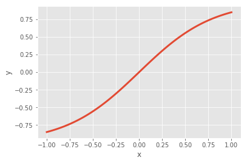

```python
# parameters for visualization
alpha = 2.5
beta = 1.0
x_sig = np.linspace(-1.0, 1.0, 100)
y_sig = beta * (1.0 - np.exp(-alpha * x_sig))
y_sig /= (1 + np.exp(-alpha * x_sig))
plt.plot(x_sig, y_sig, lw=3);
plt.xlabel('x')
plt.ylabel('y')
```

Training options via `mlp.setTrainMethod`:

- `cv2.ml.ANN_MLP_BACKPROP`: This is the backpropagation algorithm we talked about previously. You can set additional scaling factors via `mlp.setBackpropMomentumScale` and `mlp.setBackpropWeightScale`.
- `cv2.ml.ANN_MLP_RPROP`: This is the Rprop algorithm, which is short for **resilient backpropagation**. We won't have time to discuss this algorithm, but you can set additional parameters of this algorithm via `mlp.setRpropDW0`, `mlp.setRpropDWMax`, `mlp.setRpropDWMin`, `mlp.setRpropDWMinus`, and `mlp.setRpropDWPlus`.

```python
# setting the training method
mlp.setTrainMethod(cv2.ml.ANN_MLP_BACKPROP)
```

```python
# set criteria for training: run until 300 iterations or
# error doesn't increase beyond a threshold
term_mode = cv2.TERM_CRITERIA_MAX_ITER + cv2.TERM_CRITERIA_EPS
term_max_iter = 300
term_eps = 0.01
mlp.setTermCriteria((term_mode, term_max_iter, term_eps))
```

```python
# training the classifier
mlp.train(X, cv2.ml.ROW_SAMPLE, y)
# True
```

```
True
```

```python
# prediction of target labels
_, y_hat = mlp.predict(X)
```

```python
# measure accuracy
from sklearn.metrics import accuracy_score
accuracy_score(y_hat.round(), y)
# 84%
```

```
0.84
```

```python
#for visualization purposes
def plot_decision_boundary(classifier, X_test, y_test):
    # create mesh
    h = 0.02
    x_min = X_test[:, 0].min() - 1
    x_max = X_test[:, 0].max() + 1
    y_min = X_test[:, 1].min() - 1
    y_max = X_test[:, 1].max() + 1

    xx, yy = np.meshgrid(np.arange(x_min, x_max, h),\
                        np.arange(y_min, y_max, h))

    X_hypo = np.c_[xx.ravel().astype(np.float32),\
                  yy.ravel().astype(np.float32)]
    _, zz = classifier.predict(X_hypo)

    # since zz is now a one-hot encoded matrix, the
    # code must reflect this

    zz = np.argmax(zz, axis=1)

    zz = zz.reshape(xx.shape)
    plt.contourf(xx, yy, zz, cmap=plt.cm.coolwarm, alpha=0.8)
    plt.scatter(X_test[:, 0], X_test[:, 1], c=y_test, s=200)
```

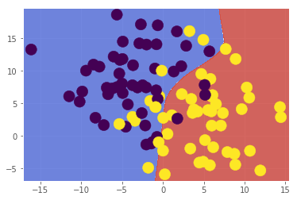

```python
# Let's see it!
plot_decision_boundary(mlp, X, y_raw)
```

## Referencias

- Beyeler, Michael. 2017. *Machine Learning for Opencv: Intelligent Image Processing with Python*. Vol. 1. Packt Publishing - ebooks Account.